# §1.5a — The Formation of the Moon: Gravity

Unit 1: Intro to the Cosmos · Astronomy

[figure not shown]

August 2, 1971. On the Moon, Apollo 15 commander Dave Scott holds up a geologist's hammer in one hand and a falcon feather in the other, and lets go of both at the same instant. On Earth the feather would drift down long after the hammer. On the Moon **they hit the ground together**.

Why would a heavy hammer and a light feather fall at exactly the same rate? Newton worked it out, and the same answer tells you how much you would weigh on the Moon, on Mars, or on any planet at all.

Today: how forces change motion, and how to find gravity on any world.

Still from the Apollo 15 TV camera, 2 Aug 1971. NASA (S71-43788)

## 1 · Gravity at a glance

🍎

Gravity on Earth

every second you fall, you go 9.8 m/s faster

🔩

Constant of gravitation

in N·m²/kg²: tiny, so you only notice gravity from something planet-sized

🌍

60× → 3600×

Newton's Moon test

the Moon is 60 times farther from Earth's center than you are, and feels 3600 times less pull

🧑‍🚀

about ⅙

Your weight on the Moon

a 100 kg astronaut weighs 161 N there, 980 N here

## 2 · Forces and gravity

Click a tile. They build in order: first how a force changes motion, then the force of gravity, then gravity on any world.

[figure not shown]

1

F = ma

a force changes motion

[figure not shown]

2

Newton's Second Law

add up the forces: ΣF

[figure not shown]

3

Force of Gravity

Newton's Moon test

[figure not shown]

4

Relative form

how many times as big?

[figure not shown]

5

Acceleration due to Gravity

g on any world, and weight

[figure not shown]

6

Weird Moon

too big for its planet

← scroll the tiles →

[figure not shown]

### F = ma

Objects are lazy. A book on a table stays put, and a hockey puck sliding on ice keeps sliding. Objects do not change their velocity on their own. They change it **only when a force acts**. Otherwise they keep doing what they are doing. That laziness is called **inertia**.

#### Newton's First Law

1. An object at rest remains at rest as long as no net force acts on it.
2. An object moving with constant velocity keeps the same speed and direction as long as no net force acts on it.

So a force changes the velocity, and a change in velocity over time is an **acceleration**. More force gives more acceleration, $a \propto F$. More mass gives less, $a \propto \dfrac{1}{m}$. Put them together:

$$a \propto \frac{F}{m} \quad\Longrightarrow\quad \boxed{F = ma}$$ Mass in kilograms (kg), acceleration in m/s². The unit of force is the **Newton**: $1\ \text{N} = 1\ \text{kg}\cdot\text{m/s}^2$.

Push the block: predict first, then push

[interactive chart not shown]

force F

mass m

your predictionm/s²

Set a force and a mass, predict the acceleration, then push.

Ex. 1 · How much force?

How much force is needed to accelerate a 70 kg person at $a = 2.0\ \text{m/s}^2$?

**Reveal**

$$F = ma = (70\ \text{kg})(2\ \text{m/s}^2) = 140\ \text{kg}\cdot\text{m/s}^2 = \boxed{140\ \text{N}}$$

Measure: your turn

How much force does it take to accelerate a 45 kg cart at $3\ \text{m/s}^2$?

N

### Newton's Second Law

There is one small catch. When more than one force acts, it is the **net force**, $\sum F$, that decides the acceleration. Add the forces, with a sign for direction: pick one direction as $+x$, and anything pointing the other way is negative.

People pushing on a block

[interactive chart not shown]

**Newton's Second Law**$$\boxed{\sum F = ma}$$Forces along a line: $\sum F_x = m a_x$. Up and down works the same way: $\sum F_y = m a_y$.

Ex. 2 · Three people and a box

Three people push and pull on a 125 kg box as shown. What is the acceleration of the box?

[interactive chart not shown]

**Reveal**

Use Newton's Second Law, with $+x$ to the right: $$\sum F_x = (-50\ \text{N}) + (85\ \text{N}) + (-110\ \text{N}) = -75\ \text{N}$$ $$-75\ \text{N} = (125\ \text{kg})\,a_x \quad\Longrightarrow\quad a_x = \frac{-75}{125} = \boxed{-0.6\ \text{m/s}^2}$$ The minus sign means the box speeds up to the **left**.

Measure: your turn

An 80 kg crate is pulled 40 N to the left, 100 N to the right, and 20 N to the left. Taking right as $+x$, what is its acceleration?

m/s²

### Force of Gravity

Newton's big idea: the force that pulls an apple down is the **same force** that holds the Moon in its orbit. He tested it with numbers. The Moon falls toward Earth (while moving sideways fast enough to keep missing) with an acceleration of only $0.0027\ \text{m/s}^2$:

$$\frac{g_{e}}{g_{m}} = \frac{9.8}{0.0027} \approx 3600$$ $$\frac{r_m}{r_e} = \frac{3.84\times10^{8}}{6.37\times10^{6}} \approx 60$$

Sixty times farther, and $60^2 = 3600$ times weaker. Gravity falls off as one over the distance squared, $F \propto \dfrac{1}{r^2}$. The masses matter too: more mass, more pull. So $F \propto \dfrac{M_E M_m}{r^2}$.

[figure not shown]

**Earth and its Moon**, from the Galileo spacecraft on its way to Jupiter. NASA/JPL (PIA00342)

Newton's Moon test: move away from Earth

[interactive chart not shown]

distance from Earth's center

#### The Universal Law of Gravity

$$\boxed{F = \frac{G M_1 M_2}{r^2}} \qquad G = 6.67\times10^{-11}\ \text{N}\cdot\text{m}^2/\text{kg}^2$$

$M_1$ and $M_2$ are the two masses and $r$ is the distance between their centers. This is the **absolute equation**: put in real numbers, get Newtons. It works for any planet or celestial body. Gravity is:

1. Always attractive.
2. Acts along the center line connecting the two bodies.
3. Equal and opposite: by Newton's third law, the Earth pulls on the Moon exactly as hard as the Moon pulls on the Earth.

Ex. 3 · Your weight on the Moon

A 100 kg astronaut stands on the Moon: $M = 7.30\times10^{22}$ kg, $R = 1.74\times10^{6}$ m. How strongly does the Moon pull on them?

**Reveal**

$$\begin{aligned} F &= \frac{GMm}{r^2} \\ &= \frac{(6.67\times10^{-11})(7.30\times10^{22})(100)}{(1.74\times10^{6})^2} \\ &= \boxed{161\ \text{N}} \end{aligned}$$ On Earth the same astronaut weighs $(100)(9.8) = 980$ N, so on the Moon they weigh about **1/6** as much.

Measure: your turn

How strongly does the Moon pull on a 60 kg student standing on it?

N

### Relative form

Sometimes you are not given the masses and radii, only **how many times** bigger they are than somewhere else. Then you do not need $G$ at all. Put in by how many times each value changes, and anything that stays the same is a 1. This is the **relative form**, and it is much easier.

Ex. 4 · Mars vs the Moon

Mars has 8.77 times the mass of the Moon and 1.95 times its radius. How many times larger is your weight on Mars than on the Moon?

**Reveal**

Your mass $m$ does not change (1). $M$ is 8.77 times as big, and $r$ is 1.95 times as big: $$F = \frac{GMm}{r^2} = \frac{(1)(8.77)(1)}{(1.95)^2} = \boxed{2.3\ \text{times as large}}$$ So the 100 kg astronaut from Ex. 3 weighs $(2.3)(161\ \text{N}) \approx 370$ N on Mars.

Build a planet: how many times your Earth weight?

mass (× Earth)

radius (× Earth)

[interactive chart not shown]

your predictiontimes

### Acceleration due to Gravity

How quickly does gravity make things speed up as they fall? Set Newton's Second Law equal to the Law of Gravity:

$$F = ma \qquad F = \frac{GMm}{r^2} = ma \qquad \frac{GM}{r^2} = a$$

**Acceleration due to gravity**$$\boxed{g = \frac{GM}{r^2}}$$$M$ is the mass of the planet (the central body) and $r$ is how far you are from its center. On the surface, $r$ is the planet's radius.

Your own mass $m$ canceled out. The acceleration **depends only on the mass of the central body and the distance to it**. A hammer and a feather fall at the same rate. On Earth the air holds the feather back; on the Moon there is no air, and Dave Scott's hammer and feather landed together.

Ex. 5 · g on Earth

Find the acceleration due to gravity for a person standing on the Earth: $M_\oplus = 5.97\times10^{24}$ kg, $R_\oplus = 6.37\times10^{6}$ m.

**Reveal**

$$g_\oplus = \frac{GM_\oplus}{R_\oplus^2} = \frac{(6.67\times10^{-11})(5.97\times10^{24})}{(6.37\times10^{6})^2} = \boxed{9.8\ \text{m/s}^2}$$

Once you know $g$, Newton's Second Law gives the force of gravity on any object straight away. This is the object's **weight**:

$$\boxed{F_g = ma = mg}$$

Ex. 6 · A bowling ball's weight

Find the weight of an 8 kg bowling ball on the Earth.

**Reveal**

$$F_g = mg = (8\ \text{kg})(9.8\ \text{m/s}^2) = \boxed{78\ \text{N}}$$

Measure: g on four worlds

Use $g = \dfrac{GM}{r^2}$ with $G = 6.67\times10^{-11}$. Type answers like `3.7`.

[output not shown]

### Weird Moon

So our Moon is far too big for a planet our size. The pictures below set every planet to the same size and draw its biggest moon to scale beside it.

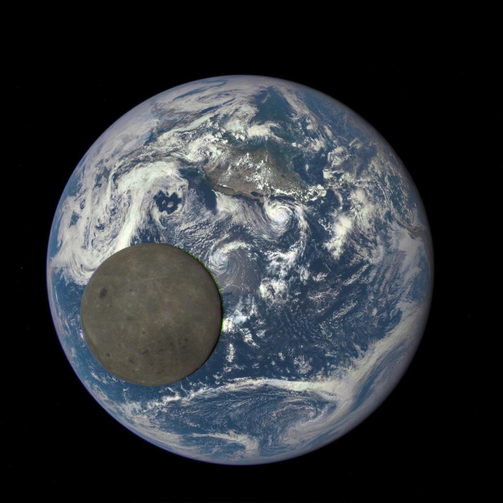

**The Moon crosses the face of the Earth**, seen by the DSCOVR spacecraft from 1.5 million km away. The Moon is a little closer to the camera, so it looks a bit bigger than its true 27%. NASA/NOAA

Every planet the same size, its biggest moon to scale

[interactive chart not shown]

Measure: how big is the Moon?

What fraction of Earth's radius is the Moon's radius? ($R_m = 1{,}740$ km, $R_\oplus = 6{,}370$ km)

**But where did the Moon come from?** A moon this big needs a special story. In §1.5b you will see how the whole solar system formed, and then line up the evidence for how our Moon got here.

## 3 · Rank the weights

One astronaut visits six worlds. Each world’s mass and radius are given **relative to Earth**. Use the relative form, $F = \dfrac{M}{r^2}$, and drag the worlds from **heaviest** weight at the top to **lightest** at the bottom.

Heaviest at the top

Drag a row (on a phone, drag it by the ⋮⋮ handle), or use the arrows.

## 4 · Self-check

**Sources and further reading**

Want to dig deeper? Each title links straight to the original.

**The hammer and the feather**

- [The Apollo 15 hammer–feather drop](https://nssdc.gsfc.nasa.gov/planetary/lunar/apollo_15_feather_drop.html) (NASA): the video of Dave Scott's test, with what he said as he let go.
- [Dave Scott watches the hammer and feather fall](https://images.nasa.gov/details/S71-43788) (NASA Image Library): the still at the top of this page.

**Forces and Newton's laws**

- [Newton's laws of motion](https://www1.grc.nasa.gov/beginners-guide-to-aeronautics/newtons-laws-of-motion/) (NASA Glenn Research Center): all three laws, with rocket and airplane examples.
- [What is gravity?](https://spaceplace.nasa.gov/what-is-gravity/en/) (NASA Space Place): a short, friendly explainer.

**Gravity on other worlds**

- [Planetary fact sheet](https://nssdc.gsfc.nasa.gov/planetary/factsheet/) (NASA Space Science Data Coordinated Archive): the masses and radii used on this page, and every planet's surface gravity to check your answers.
- [Moon facts](https://science.nasa.gov/moon/facts/) (NASA): size, mass, distance and more about our Moon.

**Weird Moon**

- [From a million miles away: the Moon crosses the face of Earth](https://images.nasa.gov/details/from-a-million-miles-away-nasa-camera-shows-moon-crossing-face-of-earth_20129140980_o) (NASA Image Library): the DSCOVR picture in the Weird Moon tile, with NASA’s description.
- [The Earth and Moon from Galileo](https://photojournal.jpl.nasa.gov/catalog/PIA00342) (NASA/JPL Photojournal): the picture in the Force of Gravity tile.
- [Pluto](https://science.nasa.gov/dwarf-planets/pluto/) (NASA): the one other world with a moon about half its size.
- [Jupiter's moons](https://science.nasa.gov/jupiter/jupiter-moons/) (NASA): lots of moons, all small next to Jupiter.

**Image credits**

- Dave Scott with the hammer and feather, Apollo 15 TV camera, 2 Aug 1971: NASA, S71-43788 (public domain).
- The Earth and Moon from Galileo: NASA/JPL, PIA00342 (public domain).
- The Moon crossing the face of the Earth: NASA/NOAA, DSCOVR EPIC, 2015 (public domain).
- All other figures are drawn on this page.